# Weekly factory production

What is the cost per product line to produce? What is the average profit per product line?

Data cleaning and consolidation

```r
# install.packages("car", "effectsize")
library(conflicted)
library(tidyverse)
conflict_prefer("filter", "dplyr")
```

```
[conflicted] Removing existing preference.[conflicted] Will prefer dplyr::filter over any other package.
```

```r
conflict_prefer("lag", "dplyr")
```

```
[conflicted] Removing existing preference.[conflicted] Will prefer dplyr::lag over any other package.
```

```r
production_metrics <- read.csv("data/weekly_factory_production.csv")
sales <- read.csv("data/sales_data_sample.csv")
View(production_metrics)
```

Sum quantity ordered and sales for each product line and do total sales/quantity = gross per then net = gross per - estimated cost per doing by total sales instead of individual price each since it ends up at the same result without needing to weight for higher value items that sell less etc.

```r
summary_product <- aggregate(sales$QUANTITYORDERED, by=list(product_line=sales$PRODUCTLINE), FUN=sum)
total_sales <- aggregate(sales$SALES, by=list(product_line=sales$PRODUCTLINE), FUN=sum)
summary_product$total_sales <- total_sales$x
summary_product$average_prices <- summary_product$total_sales/summary_product$x
```

```r
#production_metrics
```

```r
#sales
```

Filter by factory id

```r
factory_0 <-production_metrics %>% filter(factory_id == 0)
factory_0_clean <- factory_0[factory_0$outlier == 0,]
factory_1 <-production_metrics %>% filter(factory_id == 1)
factory_1_clean <-factory_1[factory_1$outlier == 0,]
factory_2 <-production_metrics %>% filter(factory_id == 2)
factory_2_clean <-factory_2[factory_2$outlier == 0,]
```

```r
lm_factory_0 <- lm(factory_0_clean$weekly_cost ~ factory_0_clean$Classic.Cars + factory_0_clean$Ships)
#lm_factory_0 <- lm(factory_0_clean$weekly_cost ~ 0 + factory_0_clean$Classic.Cars + factory_0_clean$Ships)
summary_product$average_costs <- 0
summary_product[1,]$average_costs <- summary(lm_factory_0)$coefficients["factory_0_clean$Classic.Cars", "Estimate"]
summary_product[4,]$average_costs <- summary(lm_factory_0)$coefficients["factory_0_clean$Ships", "Estimate"]
summary(lm_factory_0)
```

```
Call:
lm(formula = factory_0_clean$weekly_cost ~ factory_0_clean$Classic.Cars +
    factory_0_clean$Ships)

Residuals:
    Min      1Q  Median      3Q     Max
-348.15 -115.02  -27.46   29.60 1030.61

Coefficients:
                             Estimate Std. Error t value Pr(>|t|)
(Intercept)                   448.030     57.117   7.844 2.46e-12 ***
factory_0_clean$Classic.Cars   83.726      8.405   9.962  < 2e-16 ***
factory_0_clean$Ships          15.909      1.099  14.481  < 2e-16 ***
---
Signif. codes:  0 ‘***’ 0.001 ‘**’ 0.01 ‘*’ 0.05 ‘.’ 0.1 ‘ ’ 1

Residual standard error: 250.6 on 115 degrees of freedom
Multiple R-squared:  0.6547,    Adjusted R-squared:  0.6487
F-statistic:   109 on 2 and 115 DF,  p-value: < 2.2e-16
```

83.726 estimated cost per classic car 15.909 estimated cost per ship 448.03 estimated base weekly cost for factory_0

```r
lm_factory_1 <- lm(factory_1_clean$weekly_cost ~ factory_1_clean$Motorcycles + factory_1_clean$Trucks.and.Buses)
#lm_factory_1 <- lm(factory_1_clean$weekly_cost ~ 0 + factory_1_clean$Motorcycles + factory_1_clean$Trucks.and.Buses)
summary_product[2,]$average_costs <- summary(lm_factory_1)$coefficients["factory_1_clean$Motorcycles", "Estimate"]
summary_product[6,]$average_costs <- summary(lm_factory_1)$coefficients["factory_1_clean$Trucks.and.Buses", "Estimate"]
summary(lm_factory_1)
```

```
Call:
lm(formula = factory_1_clean$weekly_cost ~ factory_1_clean$Motorcycles +
    factory_1_clean$Trucks.and.Buses)

Residuals:
    Min      1Q  Median      3Q     Max
-171.67  -34.93  -16.13   -6.88 1136.47

Coefficients:
                                 Estimate Std. Error t value Pr(>|t|)
(Intercept)                       256.687     41.433   6.195 9.32e-09 ***
factory_1_clean$Motorcycles        75.090      2.163  34.719  < 2e-16 ***
factory_1_clean$Trucks.and.Buses   91.039      2.960  30.760  < 2e-16 ***
---
Signif. codes:  0 ‘***’ 0.001 ‘**’ 0.01 ‘*’ 0.05 ‘.’ 0.1 ‘ ’ 1

Residual standard error: 180.7 on 115 degrees of freedom
Multiple R-squared:  0.9259,    Adjusted R-squared:  0.9246
F-statistic: 718.4 on 2 and 115 DF,  p-value: < 2.2e-16
```

75.090 estimated cost per motorcycle 91.039 estimated cost per truck/bus 256.687 estimated base weekly cost for factory_1

```r
lm_factory_2 <- lm(factory_2_clean$weekly_cost ~ factory_2_clean$Vintage.Cars + factory_2_clean$Planes)
#lm_factory_2 <- lm(factory_2_clean$weekly_cost ~ 0 + factory_2_clean$Vintage.Cars + factory_2_clean$Planes)
summary_product[7,]$average_costs <- summary(lm_factory_2)$coefficients["factory_2_clean$Vintage.Cars", "Estimate"]
summary_product[3,]$average_costs <- summary(lm_factory_2)$coefficients["factory_2_clean$Planes", "Estimate"]
summary(lm_factory_2)
```

```
Call:
lm(formula = factory_2_clean$weekly_cost ~ factory_2_clean$Vintage.Cars +
    factory_2_clean$Planes)

Residuals:
    Min      1Q  Median      3Q     Max
-307.66  -37.79  -18.68    9.17 1175.95

Coefficients:
                             Estimate Std. Error t value Pr(>|t|)
(Intercept)                   546.772     59.596   9.175 2.04e-15 ***
factory_2_clean$Vintage.Cars   66.673      2.350  28.368  < 2e-16 ***
factory_2_clean$Planes         83.104      2.616  31.768  < 2e-16 ***
---
Signif. codes:  0 ‘***’ 0.001 ‘**’ 0.01 ‘*’ 0.05 ‘.’ 0.1 ‘ ’ 1

Residual standard error: 241.5 on 116 degrees of freedom
Multiple R-squared:  0.913, Adjusted R-squared:  0.9115
F-statistic:   609 on 2 and 116 DF,  p-value: < 2.2e-16
```

66.673 estimated cost per vintage car 83.104 estimated cost per plane 546.772 estimated base weekly cost for factory_2

Calculating average profit per product line (commented out lm removes the intercept, thus rolling factory base weekly cost into the estimate, but higher volume in high initial cost factories could offset initial costs, so considering the base weekly cost separately when optimizing for profitability makes sense)

```r
summary_product$average_profit_per_item <- summary_product$average_prices - summary_product$average_costs
summary_product <- summary_product[-c(5),]
summary_product
```

|  | product_line | x | total_sales | average_prices | average_costs | average_profit_per_item |
| --- | --- | --- | --- | --- | --- | --- |
| 1 | Classic Cars | 33992 | 3919615.7 | 115.30995 | 83.72603 | 31.583920 |
| 2 | Motorcycles | 11663 | 1166388.3 | 100.00757 | 75.09014 | 24.917439 |
| 3 | Planes | 10727 | 975003.6 | 90.89247 | 83.10430 | 7.788175 |
| 4 | Ships | 8127 | 714437.1 | 87.90908 | 15.90912 | 71.999960 |
| 6 | Trucks and Buses | 10777 | 1127789.8 | 104.64785 | 91.03926 | 13.608588 |
| 7 | Vintage Cars | 21069 | 1903150.8 | 90.32943 | 66.67281 | 23.656627 |

Ignoring trains for now as there is no production data

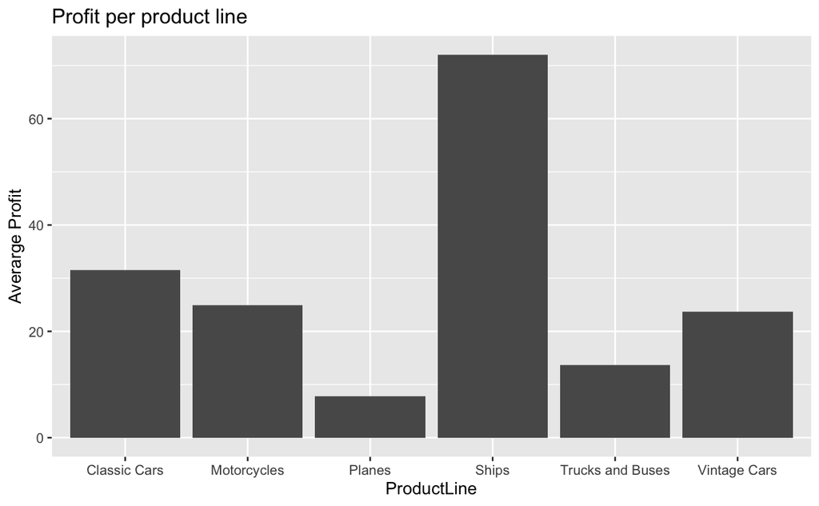

```r
ggplot(summary_product, aes(x=product_line, y = average_profit_per_item)) +
    geom_bar(stat="identity") +
    labs(x="ProductLine",
         y="Averarge Profit",
         title = "Profit per product line")
```